# Introducing Platform Surface Interior Angle and Its Role in Flake Formation, Size and Shape

Abstract

Four ways archaeologists have tried to gain insights into how flintknapping creates lithic variability are fracture mechanics, controlled experimentation, replication and attribute studies of lithic assemblages. Of the these, fracture mechanics has the advantage of being based more closely on first principles derived from physics and material sciences, but its practical application to controlled experimentation, replication and lithic studies more generally has been limited. Controlled experiments have the advantage of being able to explicitly quantify the contribution of individual variables to knapping outcomes, and the results of these experiments have provided models of flake formation that when applied to the archaeological record of flintknapping have provided insights into past behavior. Here we attempt to provide some linkage between fracture mechanics and the results of the controlled experiments to increase its explanatory and predictive power. We do this by looking for the impact of the Herztian cone of percussion, a constant in fracture mechanics, on flake platforms. We find that the platform width is a function of the Hertzian cone constant angle and the geometry of the platform edge. This finding strengthens the foundation of one of the models emerging from the controlled experiments and with some additional work should make it possible to merge more of the experimental results into a more comprehensive model.

# 1 Introduction

There is considerable literature dedicated to better understanding how flakes form. Roughly speaking, this work falls into several broad categories which we can call fracture mechanics (e.g. Cotterell and Kaminga etc., Speth 1972), controlled experiments (e.g. Speth, Pelcin, Dibble etc.), replicative experiments (e.g. Eren etc.), and attribute analysis of archaeological assemblages. These approaches have each their own strengths and weaknesses; however, one way to understand the differences between them is in the directionality of inference. Fracture mechanics starts with first principles, or laws drawn from physics and material sciences in particular, concerning how fractures should form in brittle solids to then make predictions about how flakes should look (size and shape) under varying conditions (where the core is struck, the hammer type, how the platform is prepared, the angle of strike, etc.). To the contrary, controlled and replicative experiments and studies of actual lithic assemblages look at empirical regularities in size and shape under varying conditions to build statistical models of flake formation from which one can try to infer first principles. Both approaches are, of course, valid and useful, and the relationship between what is learned from actually doing (experiments) and what is learned from knowing how it should work in principle (fracture mechanics) is circular with each informing the other in an iterative loop.

Understanding first principles causality from statistical modeling, however, is challenging. McElreath (2018) gives the example of trying to understand the physics behind race cars by measuring their attributes. Knowing the speed and handling characteristics of each car, eventually the right things could be measured on each car to build statistical models with enough predictive power to know how a new car might perform in a race, but it would be quite difficult to infer the general physical concepts (and laws) like torque, angular momentum, friction, conservation of energy, etc. from these statistical models. Of course, with prior knowledge of the physics, finding the right attributes to measure on the cars and statistical modeling are more quickly done. This is important because even when the physical laws are known, modeling them directly can be prohibitively complex or computationally expensive (e.g. air resistance) whereas experiments and statistical models can more efficiently arrive at useable solutions.

So instead, while some papers in controlled experiments in flake formation may cite papers from fracture mechanics, their approaches are all based on statistical modeling. Speth’s work on this topic makes a good example. His 1972 paper uses fracture mechanics to derive a formula to predict flake size which is then tested against a set of actual flakes from a prehistoric site. By 1975 and again in 1981, Speth has moved to experimental approaches (ball bearings on glass) and the connection back to fracture mechanics has all but disappeared. Dibble goes further and simply dismisses fracture mechanics from start as nearly irrelevant (Dibble and Whittaker 1981). Instead of looking to fracture mechanics for insights into what to study, experimental studies are being informed by replicative knappers and observations on how actual lithic assemblages vary. Dibble is explicit in stating that his experimental research is based on what knappers would have been able to control (Dibble and Whittaker 1981; Dibble 1997). Coming back to the race car analogy, we are carefully building cars controlling for engine size, wheel configurations, foils, etc., things that are generally thought to be important for making a car go fast, and then measuring their speeds. Again, though, because it is also difficult to go in the other direction (from statistical modeling to first principles), the controlled experiment papers have not produced a general model of how flakes form. Instead, we have a series of statistical models that are difficult to relate to one another. The strongest and most influential of these is the EPA-PD model.

The EPA-PD model states that flake size (mass) is primarily a function of two important variables: exterior platform angle (EPA) and platform depth (PD). Increasing either increases flake size, but the relationship between the two is geometric such that at higher values of EPA changes in PD have a greater effect on flake size. The EPA-PD model has been replicated in multiple experiments (Dibble and Whittaker 1981; Dibble and Pelcin 1995; Speth 1975, 1981), is known to work across raw material types (Dogandzic et al. 2010), is known to work in actual lithic assemblages (Dibble 1997), and is argued to have a stronger effect on flake size and shape than does core surface morphology (Pelcin 1997; Rezek et al. 2011). The EPA-PD model of flake formation, however, has some weaknesses. For instance, beveled flakes, where the area behind the platform is thinned, are not easily included into the model (Leader et al. 2017). Beveled flakes are typically larger (mass) than the EPA-PD models predicts given their lower platform depths. The EPA-PD model also does not explain why flake size and shape change with varying angles of blow (Magnani et al. 2014), and it does not account for flake width, which is obviously a major component of shape. It is also worth noting that while the percentage of variability in mass explained by the EPA-PD model is typically high in the Dibble glass experiments, it is far lower in actual lithic assemblages. It is low enough that its utility for measuring retouch intensity (i.e. knowing how much mass has been removed from a flake through retouch) is limited (Dogandzic PLOS One), and so there have been various proposals to improve the statistical modeling of flake mass from different sets of measures (Braun et al.; Dogandzig et al.; Archer et al.). Again, though, it is not really clear why one measurement technique should work better than another, and success is measured by R2 values (e.g. Muller and Clarkson; Archer). The problem is that we still do not know really how flake formation works in a way that translates to measurable attributes.

Here we propose to build on the EPA-PD model by 1) switching the focus from variables controlled by the knapper to variables that might be more directly related to flake initiation and formation and by 2) drawing insights from the fracture mechanics literature in doing so. In particular, we start with the proposal that Hertzian cones, a constant in percussive fracture mechanics, have a measurable impact on where the fracture initiates, and this in turn plays an important role in determining flake size and shape. We model this proposal as follows. When a core is struck, the fracture initially travels from the point of percussion at a fixed angle that corresponds to the Hertzian cone angle. This angle has been measured in glass at 68.5 degrees or 137 across the full cone (Roesler 1956) and is similarly reported to be 136 degrees in Cotterell and Kaminga (1987). Importantly, this angle varies only with raw material type (). Changing the type of indenter (hard versus soft hammer), the size of the indenter, or the force with which the material is struck do not change the cone angle (). Changing the angle of blow likely changes the orientation of the cone, but it does not change its angle (). When the fracture, spreading at this constant angle, encounters the core surface a fracture plane forms roughly parallel to the core surface (in other words at an angle roughly equivalent to the EPA). At this point the importance of the Hertzian cone angle quickly diminishes, and our model no longer applies. While we are unsure where exactly the Hertzian cone will first intersect the core surface, we take as our proxy of this model the location where it initiates on the platform edge (where the platform meets the core surface), and we measure the angle between the point of percussion and these two points. This angle we term the platform surface interior angle or PSIA, and our prediction is that this angle is a constant that directly follows from the Hertzian cone constant. If this model is correct, then it means that platform width is determined by the geometry of the platform edge in relation to where the core is struck. In this way, platform width is integrated into the EPA-PD model, and how PD actually impacts flake size becomes based in fracture mechanics. Additionally, this model is not without behavioral implications in that it could explain how the manipulation of the platform impacts the size and shape of flakes.

To test this model, we examine several sets of flakes, including flakes produced in the Dibble glass experiments and flakes from replication experiments, using several methods to measure the platform surface interior angle. We find that mean angle in all datasets, regardless of how it is measured, is the same (approximately 135 degrees) and quite consistent with above mentioned values for Hertzian cone formation (Cotterell and Kaminga 1987). There is some variability in the platform surface interior angle, and it is clear that this variability cannot be solely attributed to measurement error. In the Dibble glass experiments, where key variables are controlled, there is some indication that the platform surface interior angle responds to the angle of blow. Our finding is consistent with all of the empirical results of the Dibble experiments and it explains some of the patterns in those data that previously were unaccounted for. When platform surface interior angle is combined with exterior platform angle, we may have a model for flake formation that can explain a larger portion of the variability we see in stone tool assemblage and that may allow for a closer link to predictions coming from fracture mechanics.

# 2 Materials and Methods

We use the R () statistical environment to do this analysis. This paper is an rMarkdown document, and it is included in the supplementary information along with the data files needed to compile the document and replicate all of the figures, tables, and statistics.

# 3 Results

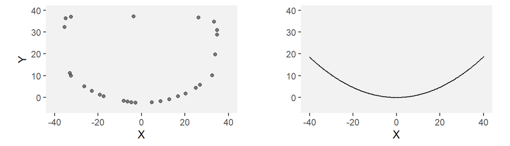

(#fig:fig-core_outlines)Outline of Dible core surface (left) and the polynominal fitted to the core edge (right).

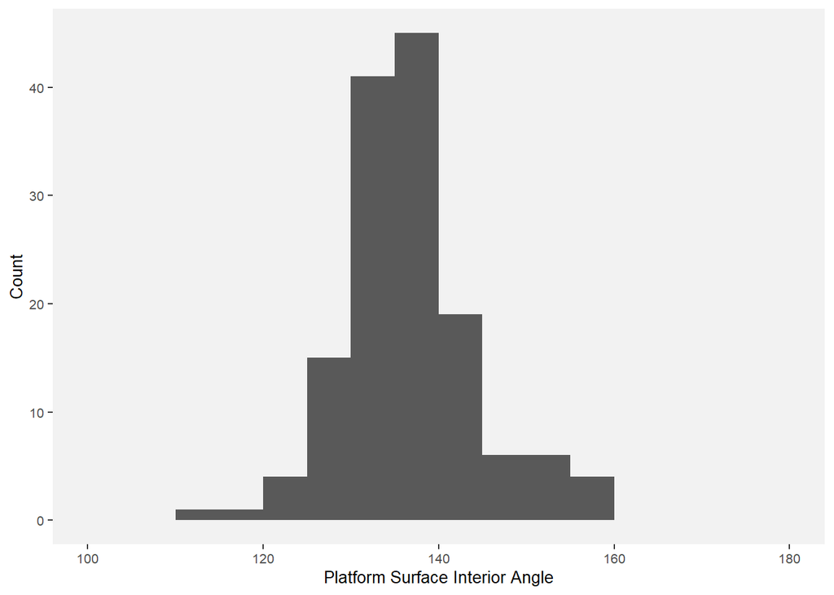

(#fig:fig-test_1_angles)Distribution of estimated platform surface interior angles (PSIA) based on the Dibble glass flakes.

Figure X shows the distribution of platform surface interior angles in the Dibble glass dataset. The distribution has a mean of 136.49 +- 7.56. Variation in this angle does not seem to be related to platform depth, exterior platform angle or mass (Figure X+1). There is a relationship between platform width and the platform surface interior angle such that larger angles result in wider platforms (see Figure X+1).

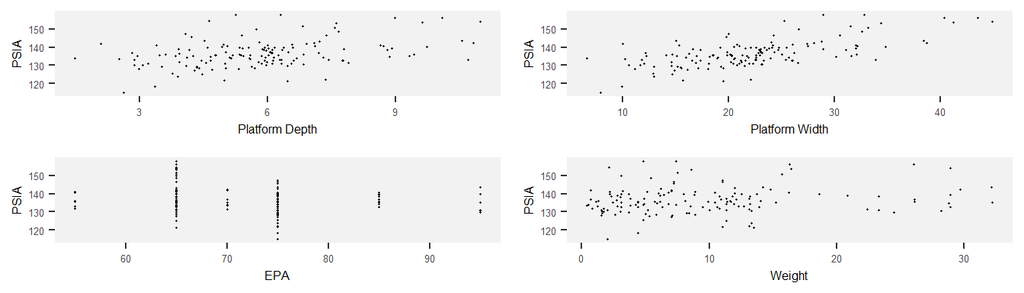

(#fig:fig-angles_to_other_measures)PW, PD, EPA and mass against the estimated platform surface interior angles based on the Dibble glass flakes.

There also appears to be a relationship between the angle of blow and the platform surface interior angle (Figure X+2). While there are fewer cases with angles of blow less than 20, there is some indication in the data that lower angles of blow are correlated with lower platform surface interior angles. After an angle of blow of 20 degrees, however, the angle of blow is not correlated with the platform surface interior angle.

```
##
## Call:
## lm(formula = angles ~ AOB + I(AOB^2), data = plot_data %>% filter(!is.na(AOB)))
##
## Residuals:
##      Min       1Q   Median       3Q      Max
## -22.2794  -4.5037  -0.9325   3.1442  20.5588
##
## Coefficients:
##               Estimate Std. Error t value Pr(>|t|)
## (Intercept) 131.326480   1.764040  74.446  < 2e-16 ***
## AOB           0.455946   0.145898   3.125  0.00217 **
## I(AOB^2)     -0.008057   0.003145  -2.562  0.01147 *
## ---
## Signif. codes:  0 '***' 0.001 '**' 0.01 '*' 0.05 '.' 0.1 ' ' 1
##
## Residual standard error: 7.367 on 138 degrees of freedom
## Multiple R-squared:  0.06955,    Adjusted R-squared:  0.05606
## F-statistic: 5.158 on 2 and 138 DF,  p-value: 0.006916
```

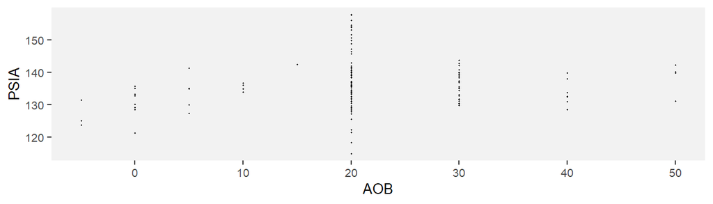

(#fig:fig-AOB_to_PSIA)AOB against the estimated platform surface interior angles based on the Dibble glass flakes.

Another way of looking at the relationship between platform width and platform surface interior angle is to calculate what the platform width would be if the platform surface interior angle is a constant and compare this to the actual platform width. We can do this by placing the point of percussion on the same platform outlines as above using the known platform depth for each of the flakes in the Dibble glass data set. We then use the average platform surface angle computed above to extend two vectors from this point of percussion to the platform edge. Where these vectors intersect the platform edge defines the left and right limits of the platform width. This estimated value is then plotted against the actual, measured platform widths (Figure X+3).

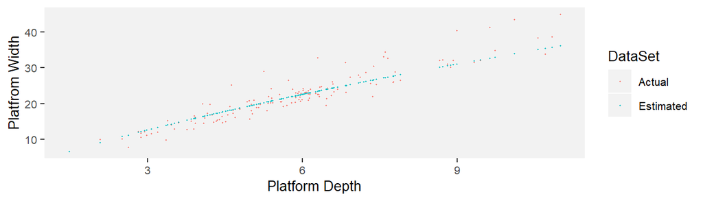

(#fig:fig-pd_pw_with_estimated_pw)The actual PD to PW data from the Dibble glass core flakes and the estimated PW using the average PSIA computed from Test 1.

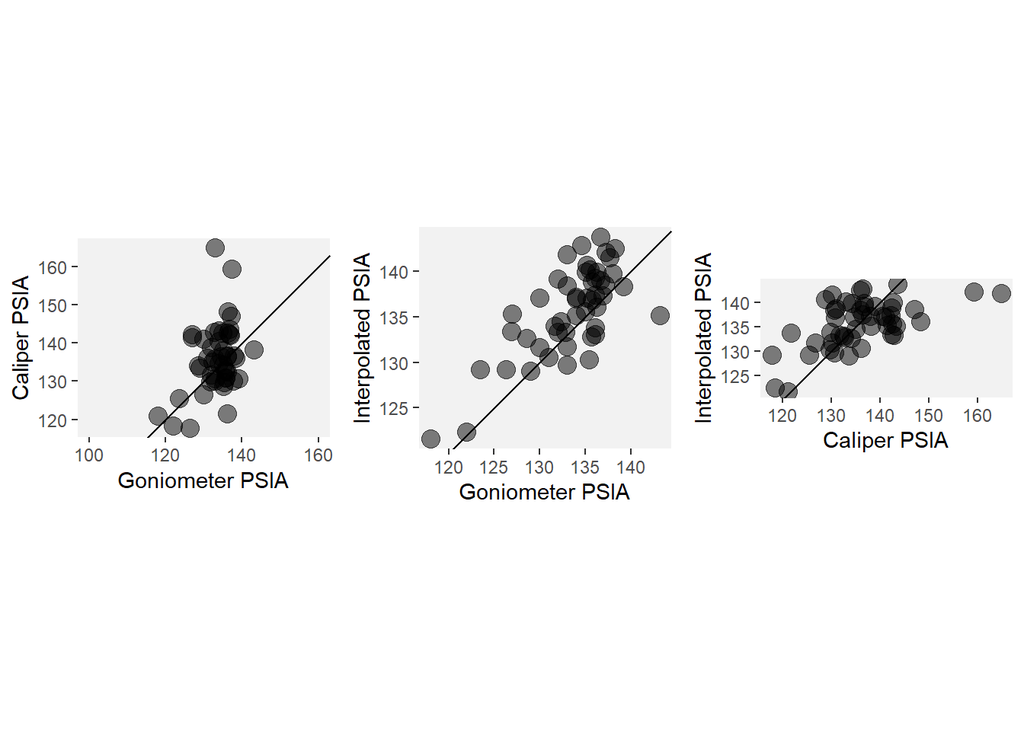

(#fig:figure_remeasure_comparisons)A comparison of the interpolated platform surface interior angle, this same angle as calculated from caliper measurements, and this same angle measured with a goniometer.

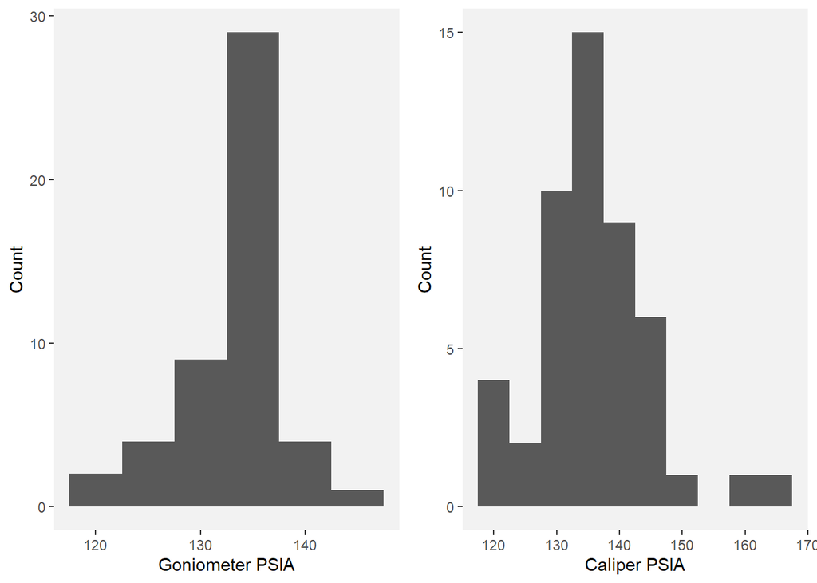

(#fig:figure_remeasure_distributions)The distributions of platform surface interior angle as directly measured with a goniometer and as calculated from caliper measurements.

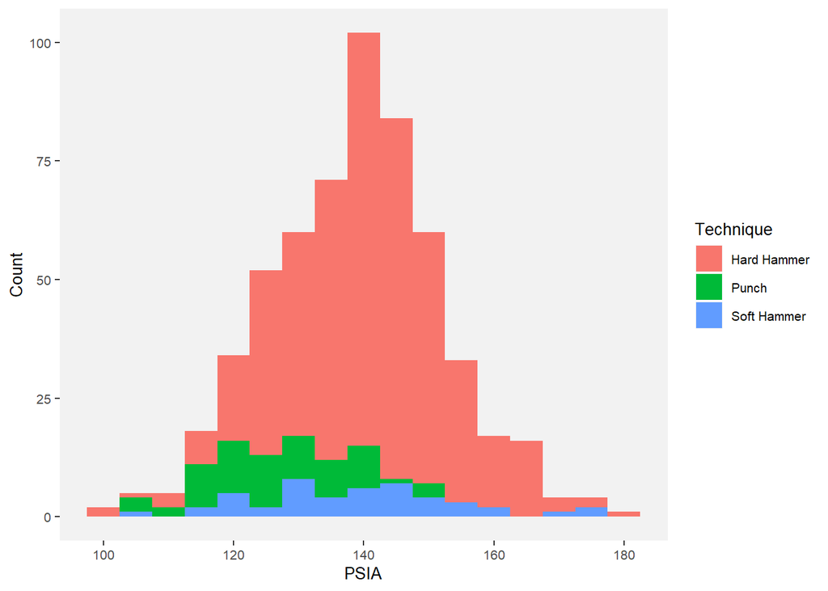

Figure 3.1: Distribution of platform surface interior angles.

In the Campagne data, platform surface interior angle does not covary with platform width, platform thickness or the shape of the platform (PW/PD). Though sample size is perhaps a problem, there is perhaps an indication that for larger platform depths, there is less variability in the platform surface interior angle.

[figure not shown]

The distribution of platform surface interior angles in the MPI dataset as measured by a digital goniometer is presented in Figure X. This dataset contains `67` flakes, and the mean is 137.75 +- 10.97, in keeping with the other datasets.

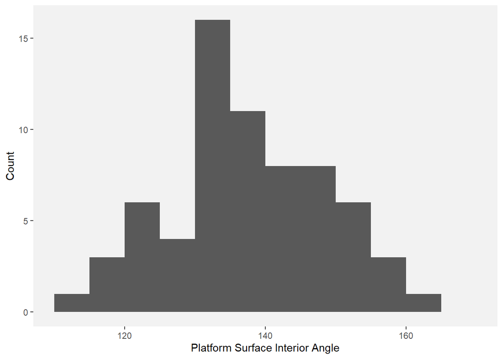

(#fig:marcel_figure)Distribution of platform surface interior angle in the MPI flakes dataset as measured by a digital goniometer.

# 4 Discussion

Each of the datasets and measurement systems used to determine the platform surface interior angle yielded very similar results, and these results are consistent with the prediction based on the already known and constant angle of Hertzian cones (135-136 degrees). These results pull platform width directly into the EPA-PD model of flake formation, but they also suggest that this model needs to be nuanced a bit. All other things being equal, in the PSIA model what determines the size of the flake is how far into the core it is struck. The deeper into the core the flake is struck, the greater the width will become because of the constant platform surface interior angle and the thicker the flake becomes as well. However, and this is the nuance, while platform thickness is normally a good proxy for how far into the core the flake is struck, it is not the same thing. Beveled flakes illustrate why this is true.

Beveled flakes are ones where material is removed behind the platform prior to striking the core. Dibble recognized that beveling altered the EPA-PD model of flake formation model such that the interaction of platform depth and exterior platform angle no longer predicted flake size (Leader et al.). Beveled flakes have too thin a platform for their size. However, the inclusion of platform surface interior angle pulls beveled flakes back into the model. Too illustrate this point, we examine some of the beveled flakes in the Dibble glass dataset.

In the Dibble glass dataset there are 11 beveled flakes coming from semispherical cores and otherwise conforming to our selection criteria. They are plotted in Figure X along with the non-beveled flakes to illustrate how the beveling changes the relationship of platform thickness to platform width. To illustrate the power of platform surface interior angle to explain these flakes, we can build a linear model to predict platform thickness from the platform surface interior angle and platform width on the non-beveled flakes in the Dibble glass dataset. We then use this model to calculate the platform thickness of the beveled flakes. However, the platform surface interior angle is not known for these flakes, and so we substitute the average PSIA in its place. When this is done, the platform thickness for the beveled flakes plot on the same trend line as the non-beveled flakes (see Figure).

This reconstructed platform thickness should then give a better estimate of flake size. We demonstrate this by first modeling flake weight as a function of exterior platform angle, platform thickness, and the interaction of two in the non-beveled flakes and plot the actual weight against the predicted weight (see Figure). Next, we use apply this model using the reconstructed platform thickness to predict the weight of the beveled flakes (see Figure).

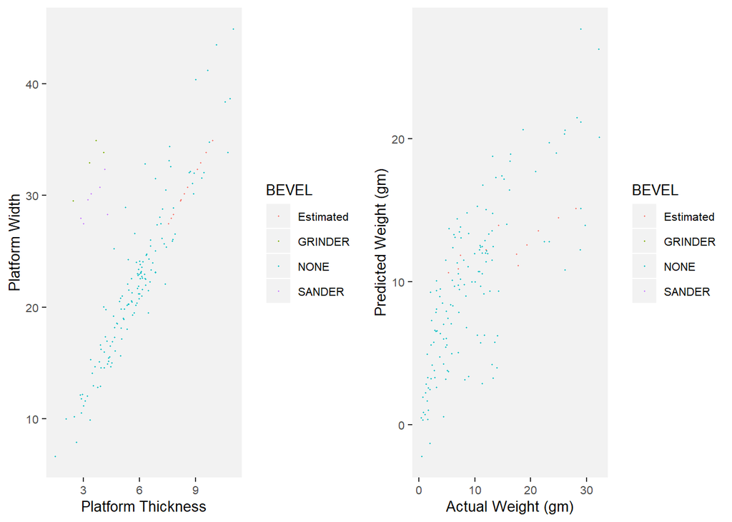

(#fig:fig-bevel_with_estimated_pd)Platform thickness to platform width including beveled flakes. Estimated points are the beveled flakes with recalculated platform thicknesses based on the average PSIA and their actual platform width.

There is some indication in the Dibble glass data that the angle of blow may impact the platform surface interior angle. At low angles of blow (perpendicular to the core surface) the platform surface interior angle is below average, and it appears to increase until an angle of between 10 and 20 degrees (from perpendicular) after which the platform surface interior angle remains essentially unchanged. With the caveat that the Dibble glass data set has very few cases with angles of less than 20 degrees, the fracture mechanics literature suggests a relationship like this. The angle of blow changes the direction though not the size of the Hertzian cone such that flakes struck from cores with a high angle of blow (oblique strike) should have “steeper and less prominent cones and less salient bulbs of percussion than flakes which are struck more steeply [or more perpendicular]” (Speth 1972:38). Experimentally, however, Magnani et al. (2014) seem to find the opposite. They report that a negative angle of blow (here values less than 0 meaning a strike directed into the core rather than towards the core surface) have smaller bulbs relative to the weight of the flake. In our Campaigne data set, we see a difference between flakes made from direct hard-hammer percussion and those made with a punch technique. The latter cluster at the low range of platform surface interior angles. This difference could be interpreted as reflecting a difference in the angle of blow in that punch flakes are much more likely to be struck perpendicularly to the platform surface. More work needs to be done, in particular analyzing Dibble glass data set where angle of blow is well controlled, but we suggest that increasing the angle of blow has the effect of tipping the direction of the Hertzian cone such that it intersects the core surface not as a circle but rather as an ellipse. Thus while the angle of the cone itself remains unchanged, its intersection with the surface broadens and results in higher platform surface interior angles. Thus, if this model is correct, striking a core with a high angle of blow will result in a larger platform width for a given platform thickness. The direct measurement of platform surface interior angle in a subsample of the Dibble glass flakes shows that our method for finding this angle using the core morphology and platform depth is working. However, there is variability in this angle depending on how it is measured. In general it seems that the direct measurement with a goniometer performs better than the indirect calculation of the angle from three caliper measurements. Of the two systems, the caliper measurements show greater variability than do the goniometer measurements. The caliper method can also fail completely when measurement error produces a triangle with impossible side lengths (e.g. the sum of the two shorter sides does not equal the length of the longest side). Importantly too, this is only knowable once the measures are taken and an angle is calculated, making it much more difficult to correct, whereas the goniometer method produces an angle each time. Our study, however, does not indicate which of the three methods in this case is correct, nor do we know the error associated with any of these methods. Now that platform surface interior angle seems to produce results relevant to understanding flake formation, additional studies are required to better know the error distribution on an individual measure. We note too that this error distribution will likely vary with the angle itself, the size of the point of percussion, and other factors that remain to be identified. The question, however, is whether this measurement error will overwhelm patterns, for instance, showing a potential correlation in angle of blow and platform surface interior angle. It is our expectation that with a digital goniometer, direct measurement of the platform surface interior angle can become a standard measurement within an attribute analysis, but this remains to be determined.

We note that our finding that the platform surface interior angle varies around a constant derived from fracture mechanics appears to be consistent with all of the findings to date of the Dibble glass experiments (). Additionally, it perhaps helps explain or account for one of the more counter intuitive finds of the glass experiments, namely that flake size (mass) is not impacted by the force with which the core is struck (Dibble and Rezek 2009). In the EPA-PD model, the amount of force required to remove a flake given a particular combination of EPA-PD is a constant. Subtracting force means that the flake is not initiated. Adding force does not change how the shape (size and mass) of the resulting flake. This makes sense in the PSIA addition to the model. In fracture mechanics, it is known that striking a material harder does not change the angle of the cone. It will change its size but not the angle. Thus when a core is struck, how far into the core the Hertzian cone travels will be a function of force, but where it is destined to intersect the core surface does not change. So striking a Dibble glass core harder at a particular point does not change the platform width, and as a result, the subsequent fracture plane that removes the flake has much less freedom to change the size of the flake.

# 5 Conclusions

Fracture mechanics is a massive field of study with both great potential and great difficulties for understanding flake formation. The potential is that the physical laws and models coming from fracture mechanics are, ultimately, how the actions of knappers are translated to usable flakes. The difficulties are both inherent to the field itself and the complexity of the problem (some solutions require more time and computing power than exists) and relate to the challenges of interdisciplinary work where the equations and goals of one field are terribly difficult to bring into another. This later point is clearly seen in the early fracture mechanics literature and the minimal impact it has had on experimental and replicative studies of flake formation.

This said, our goal here was to return to this literature and to try to find some useful insights that could be translated to a better understanding of the underlying mechanisms (or first principals) of flake formation and that might thereby lead to a better integration of the various statistical models currently in use. To do this, we discarded the existing focus in the experimental literature on what knappers do and instead focused on attributes that may be more directly related to fracture mechanics. Thus we focused our attention on Hertzian percussion cone as a constant and wondered if it could help explain platform width, an aspect of flake size and shape that up to now has been absent from the dominant EPA-PD model of flake formation. We measured three different collections in multiple different ways and found that in each case the angle formed by the platform width and the point of percussion to be, on average, essentially the same as what is predicted from fracture mechanics for the angle of the Hertzian cone.

We conclude that the platform surface interior angle is an important determinant in flake size and shape. While it would seem that it is a constant and not under direct control by the knapper, the knapper is exploiting the properties of this angle when preparing the platform and its contact with the platform surface and when deciding how far into the core to strike. In our model, this is how the PD side of the EPA-PD model of flake formation is translated into a flake of a particular size and shape. In other words, it is not the PD that directly structures flake size but rather PD is proxy for how far into the core a flake is struck which then, through the platform surface interior angle, structures the size and shape of the flake.

# 6 Acknowledgements

The knappers in Campaigne. Max Planck Society. Jean-Jacques. Sadly Harold Dibble died before the main findings of this paper were discovered. However, without his vision and his efforts to build a data set of flakes made under controlled conditions, this paper would not have been possible. We dedicate this paper to him.

# 7 References